# Overview

# Multicolinearity

One issue I dealt with working with this data set was the sheer number of variables, which you can get a sense of from the corrplot below.

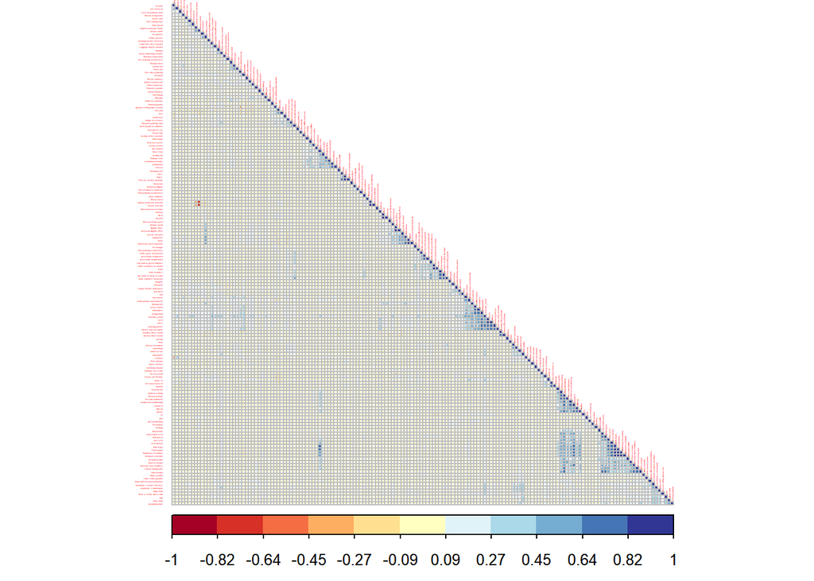

Even when we examine amenities only and drop variables with a near-zero variance, we still have a lot of variables to work with. However, we can begin to get the sense of some clusters of related variables within the dataset.

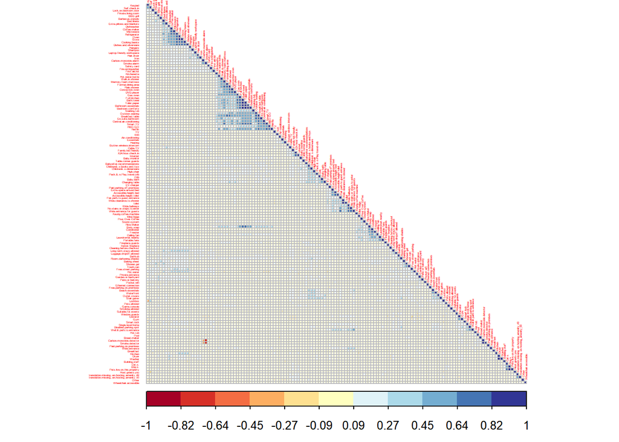

We see a fairly high correlation between certain categories of children’s amenities (Baby baths with changing tables, for example), but not necessarily others (see changing tables and bathtubs), suggesting that owners may view some mixes of amenities as redundant.

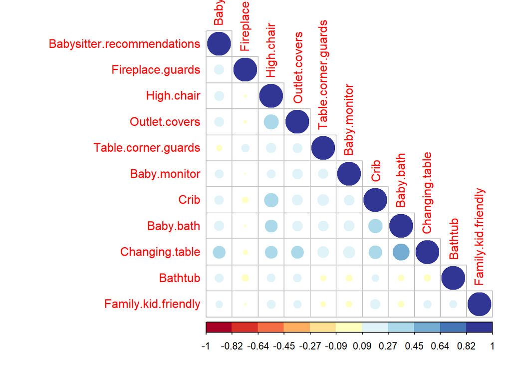

We also see correlations between access-related amenities that correspond to different locations within the listing, suggesting some possible redundancy in listings or that landlords are willing to make their properties more accessible when possible, but possibly unwilling or unable to ensure complete accessibility in many instances.

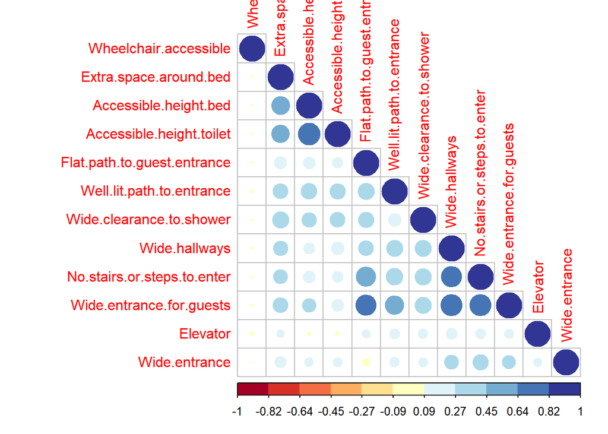

Not a lot of relationships here. Everything presumed incidental.

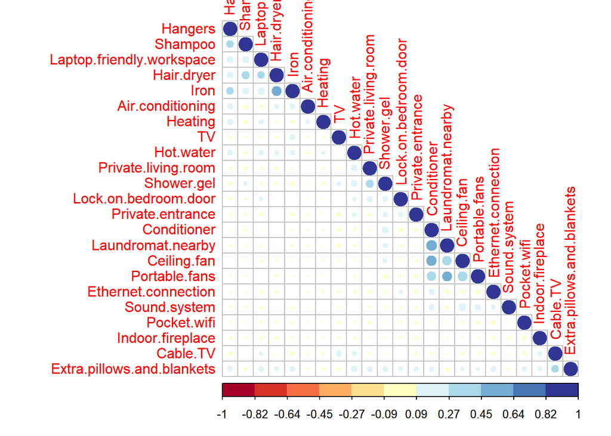

Lots of obvious relationships in the kitchen - listings with ovens tend to have stoves, cooking basics, microwaves, and refrigerators and there’s a strong relationship between microwave and coffee machines. Interestingly, there isn’t much of a relationship between listings that offer a Keurig or pour-over coffee and more complete kitchen amenities, suggesting that these may be more frequently offered in listings that offer a small coffee/snack station but not a full-service kitchen, or, alternatively, that owners aren’t very specific about the kinds of coffee in their listings.

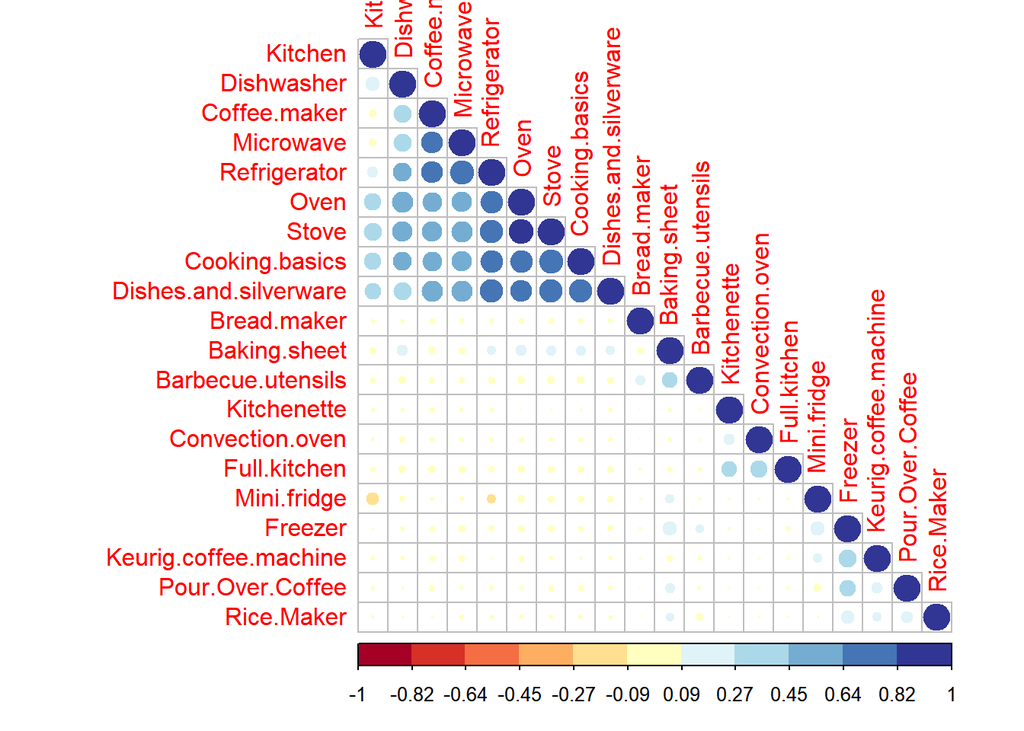

Amenities “Full Kitchen” and “Kitchenette” only apear on listings that also have “Kitchen”, suggesting that they are probably modifiers on the “Kitchen” feature.

```r
df_l1%>%filter(Kitchen == 1)%>%
  summarise(Kitchens=n())
```

```
##   Kitchens
## 1     1409
```

```r
df_l1%>%filter(Full.kitchen == 1)%>%
  summarise(Full.Kitchens=n())
```

```
##   Full.Kitchens
## 1            32
```

```r
df_l1%>%filter(Kitchen == 1)%>%
     filter(Full.kitchen==1)%>%
  summarise(KitchenNFullKitchen=n())
```

```
##   KitchenNFullKitchen
## 1                  32
```

```r
df_l1%>%filter(Kitchenette == 1)%>%
  summarise(Kitchenette=n())
```

```
##   Kitchenette
## 1           7
```

```r
df_l1%>%filter(Kitchen == 1)%>%
     filter(Kitchenette==1)%>%
  summarise(KitchenNKitchenette=n())
```

```
##   KitchenNKitchenette
## 1                   7
```

```r
df_l1%>%filter(Full.kitchen == 1)%>%
     filter(Kitchenette==1)%>%
  summarise(FullKitchenNKitchenette=n())
```

```
##   FullKitchenNKitchenette
## 1                       5
```

```r
df_kitchen%>%filter(Kitchenette==1)
```

```
##   Baking.sheet Barbecue.utensils Bread.maker Coffee.maker Convection.oven
## 1            0                 0           0            1               0
## 2            0                 0           0            1               0
## 3            0                 0           0            1               0
## 4            0                 0           0            1               0
## 5            0                 0           0            1               0
## 6            0                 0           0            1               0
## 7            0                 0           0            1               1
##   Cooking.basics Dishes.and.silverware Dishwasher Freezer Full.kitchen
## 1              1                     1          1       0            1
## 2              0                     1          0       0            0
## 3              0                     1          0       0            0
## 4              1                     1          1       0            1
## 5              1                     1          1       0            1
## 6              1                     1          1       0            1
```

[output cut: 17 more lines]

The same thing appears to be true for ovens and convection ovens.

```r
df_l1%>%filter(Oven == 1)%>%
  summarise(Oven=n())
```

```
##   Oven
## 1 1087
```

```r
df_l1%>%filter(Convection.oven == 1)%>%
  summarise(Convection.oven=n())
```

```
##   Convection.oven
## 1               5
```

```r
df_l1%>%filter(Oven == 1)%>%
     filter(Convection.oven==1)%>%
  summarise(Ovens=n())
```

```
##   Ovens
## 1     5
```

Some obvious correlations in facilities - listings with pools were more likely to have gyms and hottubs. Listings with gyms were less likely to offer free street parking, suggesting that they typically come in larger buildings in the city center where street parking isn’t available.

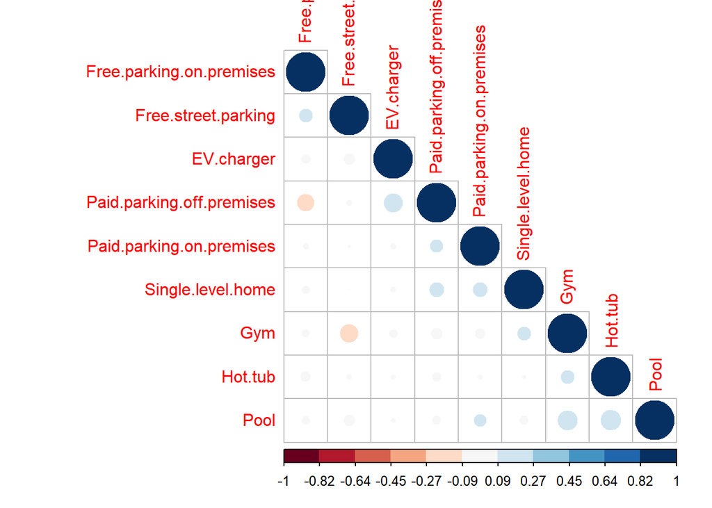

Unsurprisingly, listings with an exterior space are more likely to own a grill.

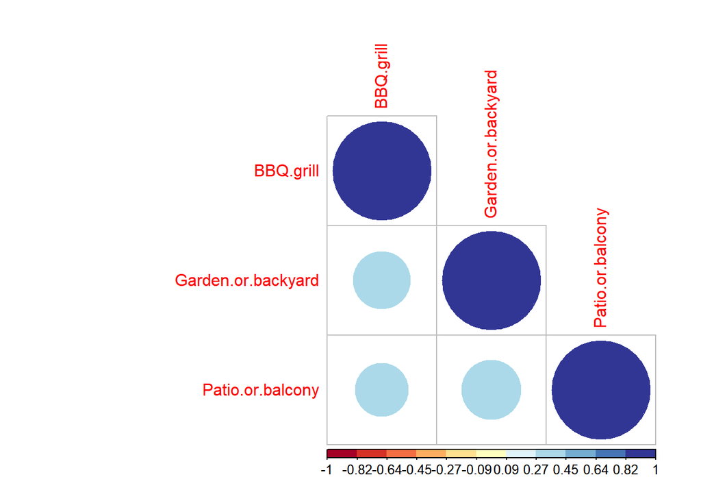

[output not shown]

[output cut: 737 more lines]

[output not shown]

# Imputation Graphs

After cleaning less than 1% of the dataset was null/NA. Missing values were imputed using KNN with euclidean distance used as a metric and 3-6 nearby features selected by correlation for each variable, or by imputing the median. Pre- and post-imputation distributions are available below.

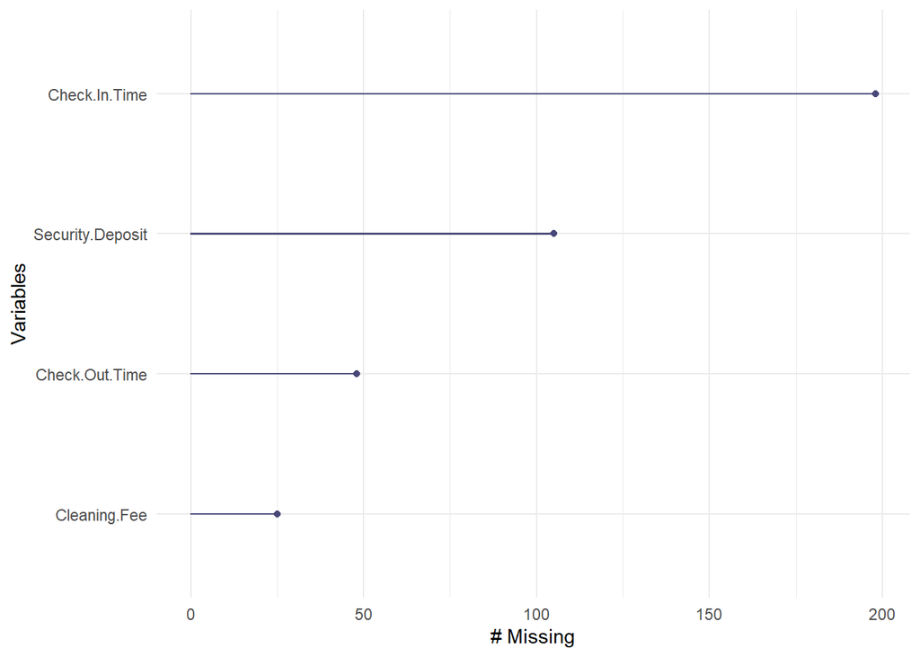

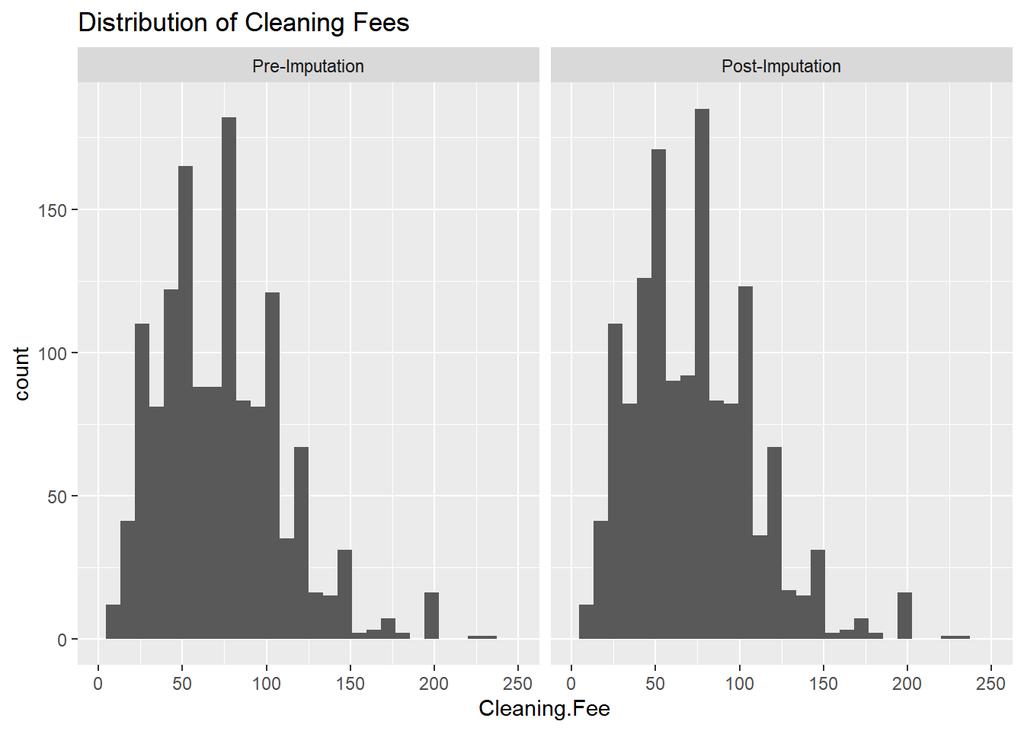

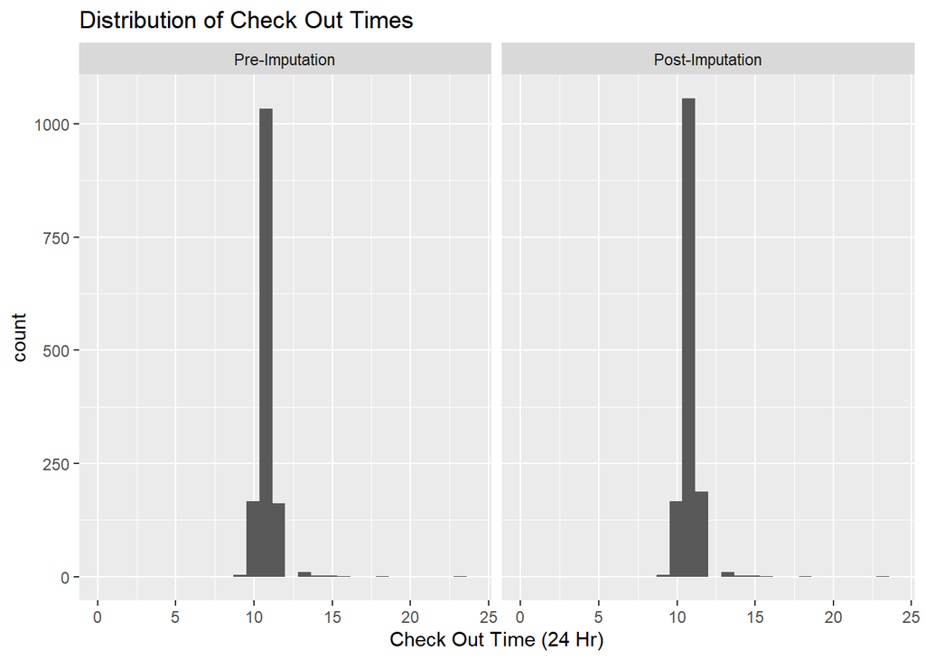

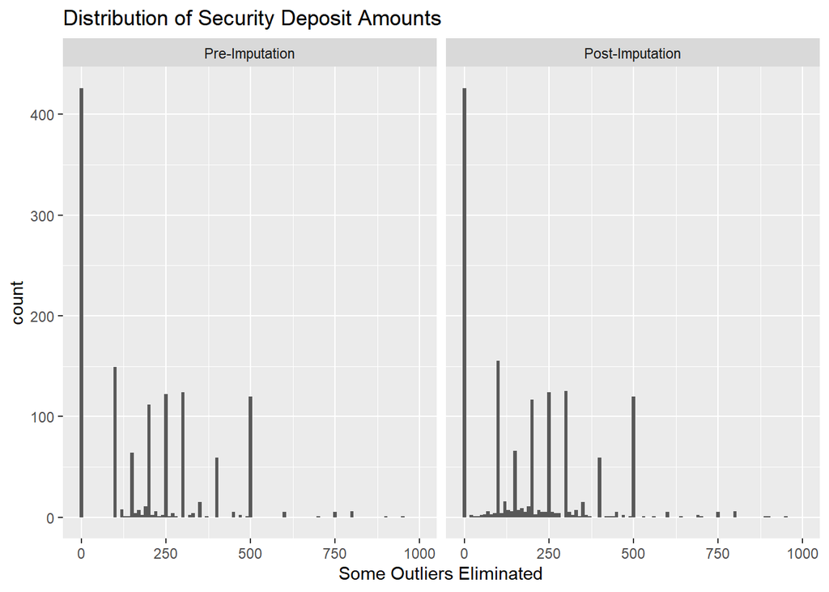

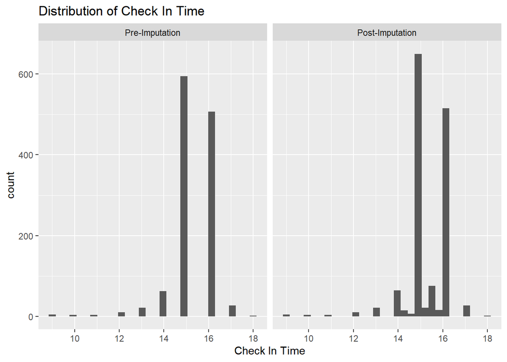

```r
summary(aov(rental_income ~ zipcode , data = df_l0))
```

```
##               Df    Sum Sq Mean Sq F value Pr(>F)
## zipcode        1 7.099e+05  709879   0.344  0.558
## Residuals   1472 3.036e+09 2062656
## 23 observations deleted due to missingness
```

```r
summary(aov(price ~ zipcode , data = df_l0))
```

```
##               Df   Sum Sq Mean Sq F value Pr(>F)
## zipcode        1    17048   17048   0.912   0.34
## Residuals   1495 27936925   18687
```

```r
summary(aov(listing_weekend_price_native ~ zipcode , data = df_l0))
```

```
##              Df   Sum Sq Mean Sq F value Pr(>F)
## zipcode       1    33414   33414   1.735  0.188
## Residuals   689 13269497   19259
## 806 observations deleted due to missingness
```

```r
summary(aov(rental_income ~ city , data = df_l0))
```

```
##               Df    Sum Sq Mean Sq F value Pr(>F)
## city           7 9.796e+06 1399453   0.678  0.691
## Residuals   1466 3.027e+09 2064900
## 23 observations deleted due to missingness
```

```r
summary(aov(price ~ city , data = df_l0))
```

```
##               Df   Sum Sq Mean Sq F value Pr(>F)
## city           7    23892    3413   0.182  0.989
## Residuals   1489 27930081   18758
```

```r
summary(aov(listing_weekend_price_native ~ city , data = df_l0))
```

```
##              Df   Sum Sq Mean Sq F value Pr(>F)
## city          5    47998    9600   0.496  0.779
## Residuals   685 13254913   19350
## 806 observations deleted due to missingness
```

```r
summary(aov(rental_income ~ city , data = df_l0))
```

```
##               Df    Sum Sq Mean Sq F value Pr(>F)
## city           7 9.796e+06 1399453   0.678  0.691
## Residuals   1466 3.027e+09 2064900
## 23 observations deleted due to missingness
```

```r
summary(aov(price ~ city , data = df_l0))
```

```
##               Df   Sum Sq Mean Sq F value Pr(>F)
## city           7    23892    3413   0.182  0.989
## Residuals   1489 27930081   18758
```

```r
summary(aov(listing_weekend_price_native ~ city , data = df_l0))
```

```
##              Df   Sum Sq Mean Sq F value Pr(>F)
## city          5    47998    9600   0.496  0.779
## Residuals   685 13254913   19350
## 806 observations deleted due to missingness
```

```r
summary(aov(rental_income ~ bed_type_category , data = df_l0))
```

```
##                     Df    Sum Sq Mean Sq F value Pr(>F)
## bed_type_category    3 5.061e+06 1686902   0.818  0.484
## Residuals         1470 3.032e+09 2062503
## 23 observations deleted due to missingness
```

```r
summary(aov(price ~ bed_type_category , data = df_l0))
```

```
##                     Df   Sum Sq Mean Sq F value Pr(>F)
## bed_type_category    3    23589    7863    0.42  0.738
## Residuals         1493 27930384   18708
```

```r
summary(aov(listing_weekend_price_native ~ bed_type_category , data = df_l0))
```

```
##                    Df   Sum Sq Mean Sq F value Pr(>F)
## bed_type_category   2    47668   23834   1.237  0.291
## Residuals         688 13255243   19266
## 806 observations deleted due to missingness
```

```r
summary(aov(occupancy ~ bed_type_category , data = df_l0))
```

```
##                     Df Sum Sq Mean Sq F value Pr(>F)
## bed_type_category    3   1856   618.6   1.134  0.334
## Residuals         1469 801543   545.6
## 24 observations deleted due to missingness
```

```r
summary(aov(rental_income ~ require_guest_phone_verification , data = df_l0))
```

```
##                                    Df    Sum Sq Mean Sq F value Pr(>F)
## require_guest_phone_verification    1 1.046e+05  104621   0.051  0.822
## Residuals                        1472 3.037e+09 2063067
## 23 observations deleted due to missingness
```

```r
summary(aov(price ~ require_guest_phone_verification , data = df_l0))
```

```
##                                    Df   Sum Sq Mean Sq F value Pr(>F)
## require_guest_phone_verification    1     1158    1158   0.062  0.804
## Residuals                        1495 27952815   18698
```

```r
summary(aov(listing_weekend_price_native ~ require_guest_phone_verification , data = df_l0))
```

```
##                                   Df   Sum Sq Mean Sq F value Pr(>F)
## require_guest_phone_verification   1       73      73   0.004  0.951
## Residuals                        689 13302839   19307
## 806 observations deleted due to missingness
```

```r
summary(aov(occupancy ~ require_guest_phone_verification , data = df_l0))
```

```
##                                    Df Sum Sq Mean Sq F value Pr(>F)
## require_guest_phone_verification    1     98    97.5   0.179  0.673
## Residuals                        1471 803302   546.1
## 24 observations deleted due to missingness
```

```r
summary(aov(rental_income ~ is_location_exact , data = df_l0))
```

```
##                     Df    Sum Sq Mean Sq F value Pr(>F)
## is_location_exact    1 1.162e+05  116193   0.056  0.812
## Residuals         1472 3.037e+09 2063059
## 23 observations deleted due to missingness
```

```r
summary(aov(price ~ is_location_exact , data = df_l0))
```

```
##                     Df   Sum Sq Mean Sq F value Pr(>F)
## is_location_exact    1    43086   43086   2.308  0.129
## Residuals         1495 27910887   18669
```

```r
summary(aov(listing_weekend_price_native ~ is_location_exact , data = df_l0))
```

```
##                    Df   Sum Sq Mean Sq F value Pr(>F)
## is_location_exact   1    63490   63490   3.304 0.0695 .
## Residuals         689 13239422   19215
## ---
## Signif. codes:  0 '***' 0.001 '**' 0.01 '*' 0.05 '.' 0.1 ' ' 1
## 806 observations deleted due to missingness
```

```r
summary(aov(occupancy ~ is_location_exact , data = df_l0))
```

```
##                     Df Sum Sq Mean Sq F value Pr(>F)
## is_location_exact    1   1154  1153.9   2.116  0.146
## Residuals         1471 802245   545.4
## 24 observations deleted due to missingness
```

```r
summary(aov(rental_income ~ instant_bookable , data = df_l0))
```

```
##                    Df    Sum Sq Mean Sq F value Pr(>F)
## instant_bookable    1 8.784e+05  878350   0.426  0.514
## Residuals        1472 3.036e+09 2062542
## 23 observations deleted due to missingness
```

```r
summary(aov(price ~ instant_bookable , data = df_l0))
```

```
##                    Df   Sum Sq Mean Sq F value Pr(>F)
## instant_bookable    1    24200   24200   1.295  0.255
## Residuals        1495 27929773   18682
```

```r
summary(aov(listing_weekend_price_native ~ instant_bookable , data = df_l0))
```

```
##                   Df   Sum Sq Mean Sq F value   Pr(>F)
## instant_bookable   1   222901  222901   11.74 0.000648 ***
## Residuals        689 13080010   18984
## ---
## Signif. codes:  0 '***' 0.001 '**' 0.01 '*' 0.05 '.' 0.1 ' ' 1
## 806 observations deleted due to missingness
```

```r
summary(aov(occupancy ~ instant_bookable , data = df_l0))
```

```
##                    Df Sum Sq Mean Sq F value Pr(>F)
## instant_bookable    1    103   103.0   0.189  0.664
## Residuals        1471 803296   546.1
## 24 observations deleted due to missingness
```

```r
summary(aov(rental_income ~ require_guest_profile_picture , data = df_l0))
```

```
##                                 Df    Sum Sq Mean Sq F value Pr(>F)
## require_guest_profile_picture    1 2.020e+05  201993   0.098  0.754
## Residuals                     1472 3.037e+09 2063001
## 23 observations deleted due to missingness
```

```r
summary(aov(price ~ require_guest_profile_picture , data = df_l0))
```

```
##                                 Df   Sum Sq Mean Sq F value Pr(>F)
## require_guest_profile_picture    1       59      59   0.003  0.955
## Residuals                     1495 27953913   18698
```

```r
summary(aov(listing_weekend_price_native ~ require_guest_profile_picture , data = df_l0))
```

```
##                                Df   Sum Sq Mean Sq F value Pr(>F)
## require_guest_profile_picture   1      341     341   0.018  0.894
## Residuals                     689 13302570   19307
## 806 observations deleted due to missingness
```

```r
summary(aov(occupancy ~ require_guest_profile_picture , data = df_l0))
```

```
##                                 Df Sum Sq Mean Sq F value Pr(>F)
## require_guest_profile_picture    1    435   435.1   0.797  0.372
## Residuals                     1471 802964   545.9
## 24 observations deleted due to missingness
```

```r
summary(aov(rental_income ~ description_locale , data = df_l0))
```

```
##                      Df    Sum Sq Mean Sq F value Pr(>F)
## description_locale    4 9.158e+06 2289568   1.111   0.35
## Residuals          1469 3.028e+09 2061117
## 23 observations deleted due to missingness
```

```r
summary(aov(price ~ description_locale , data = df_l0))
```

```
##                      Df   Sum Sq Mean Sq F value Pr(>F)
## description_locale    4    25500    6375   0.341  0.851
## Residuals          1492 27928472   18719
```

```r
summary(aov(listing_weekend_price_native ~ description_locale , data = df_l0))
```

```
##                     Df   Sum Sq Mean Sq F value Pr(>F)
## description_locale   3    11095    3698   0.191  0.902
## Residuals          687 13291817   19348
## 806 observations deleted due to missingness
```

```r
summary(aov(occupancy ~ description_locale , data = df_l0))
```

```
##                      Df Sum Sq Mean Sq F value Pr(>F)
## description_locale    4   4049  1012.2   1.859  0.115
## Residuals          1468 799350   544.5
## 24 observations deleted due to missingness
```

```r
summary(aov(rental_income ~ locale , data = df_l0))
```

```
##               Df    Sum Sq  Mean Sq F value   Pr(>F)
## locale         7 8.196e+07 11707967   5.808 1.17e-06 ***
## Residuals   1466 2.955e+09  2015678
## ---
## Signif. codes:  0 '***' 0.001 '**' 0.01 '*' 0.05 '.' 0.1 ' ' 1
## 23 observations deleted due to missingness
```

```r
summary(aov(price ~ locale , data = df_l0))
```

```
##               Df   Sum Sq Mean Sq F value Pr(>F)
## locale         7   122317   17474   0.935  0.478
## Residuals   1489 27831656   18692
```

```r
summary(aov(listing_weekend_price_native ~ locale , data = df_l0))
```

```
##              Df   Sum Sq Mean Sq F value Pr(>F)
## locale        5   260917   52183   2.741 0.0184 *
## Residuals   685 13041994   19039
## ---
## Signif. codes:  0 '***' 0.001 '**' 0.01 '*' 0.05 '.' 0.1 ' ' 1
## 806 observations deleted due to missingness
```

```r
summary(aov(occupancy ~ locale , data = df_l0))
```

```
##               Df Sum Sq Mean Sq F value Pr(>F)
## locale         7   3443   491.8   0.901  0.505
## Residuals   1465 799957   546.0
## 24 observations deleted due to missingness
```

```r
summary(aov(rental_income ~ max_nights , data = df_l0))
```

```
##               Df    Sum Sq Mean Sq F value Pr(>F)
## max_nights     1 2.035e+05  203533   0.099  0.753
## Residuals   1472 3.037e+09 2063000
## 23 observations deleted due to missingness
```

```r
summary(aov(price ~ max_nights , data = df_l0))
```

```
##               Df   Sum Sq Mean Sq F value Pr(>F)
## max_nights     1    53006   53006    2.84 0.0921 .
## Residuals   1495 27900967   18663
## ---
## Signif. codes:  0 '***' 0.001 '**' 0.01 '*' 0.05 '.' 0.1 ' ' 1
```

```r
summary(aov(listing_weekend_price_native ~ max_nights , data = df_l0))
```

```
##              Df   Sum Sq Mean Sq F value Pr(>F)
## max_nights    1    25205   25205   1.308  0.253
## Residuals   689 13277706   19271
## 806 observations deleted due to missingness
```

```r
summary(aov(occupancy ~ max_nights , data = df_l0))
```

```
##               Df Sum Sq Mean Sq F value Pr(>F)
## max_nights     1   1500  1500.4   2.752 0.0973 .
## Residuals   1471 801899   545.1
## ---
## Signif. codes:  0 '***' 0.001 '**' 0.01 '*' 0.05 '.' 0.1 ' ' 1
## 24 observations deleted due to missingness
```

In order to improve modeling on non-tree models I dropped amenities with near-zero variance, listed below.

```
##  [1] "Amazon.Echo"                    "Balcony"
##  [3] "Day.bed"                        "Espresso.machine"
##  [5] "Fire.pit"                       "Firm.mattress"
##  [7] "Fixed.grab.bars.for.shower"     "Hand.Sanitiser"
##  [9] "Handheld.shower.head"           "Heat.lamps"
## [11] "Heated.floors"                  "Jetted.tub"
## [13] "Mudroom"                        "Murphy.bed"
## [15] "Nespresso.machine"              "Other.pet.s."
## [17] "Outdoor.parking"                "Piano"
## [19] "Pillow.top.mattress"            "Playground"
## [21] "Printer"                        "Record.player"
## [23] "Roll.in.shower"                 "Terrace"
## [25] "Trash.compacter"                "Wide.doorway.to.guest.bathroom"
## [27] "Wide.entryway"
```